# FordGoBike Data Trends Visualization

## by Fahad Bakoor

## Investigation Overview

> Ford GoBike is a regional public bicycle sharing system in the San Francisco Bay Area, California. Beginning operation in August 2013 as Bay Area Bike Share, we will investigate The duration of Biking, the distribution of trips over periods, and the user's traits.

## Dataset Overview

> the data set I'm using today is for February 2019, which covers info about trips taken by service members, their types, their age, their gender, stations of starting and ending trips, duration of trips, etc.

## Histogram of trip duration in minutes

### Remarks

- Most of the trips are below 15 min
- The avrage trip is 11.7 min
- The longest trip was 1409 min (23 hours 29 minutes)
- The shortest trip was 1 min

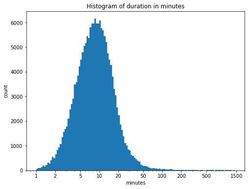

## Trip Duration across different weekdays and hours¶

### Remarks

- riders on Sunday and Saturday on average have the longest trip duration
- riders on 2 AM and 3 AM on average have the longest trip duration
- Sunday 3 AM have the longest trip average

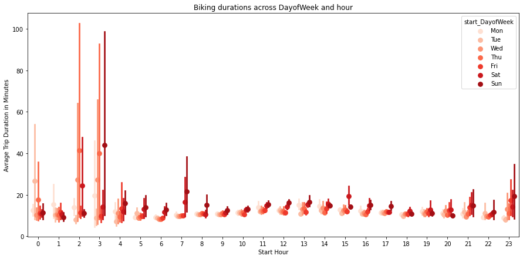

## Trip duration across different ages scatterplot

### Remarks

- Younger riders (18 to 50) tend to have longer trips
- trip duration start to drop after the age 50

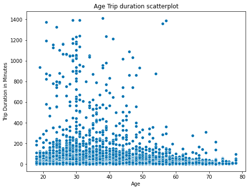

[output not shown]